# CM3015 Machine Learning and Neural Networks: End-Term Coursework

1. Introduction
   1. Problem and Dataset
   2. Measure of Success
   3. Evaluation Protocol
2. Methodology
   1. Preparing the Data
   2. Developing a Model
   3. Developing an Overfitting Model
   4. Regularizing the Model and Hyperparameter Tuning
3. Results
4. Conclusion

## Introduction

For this coursework, I will be following *“The universal workflow of machine learning”* from Deep Learning With Python by François Chollet. The workflow goes as such:

1. Defining the problem and assembling a dataset
2. Choosing a measure of success
3. Deciding on an evaluation protocol
4. Preparing your data
5. Developing a model that does better than baseline
6. Scaling up: developing a model that overfits
7. Regularizing your model and tuning your hyperparameters

### Problem and Dataset

I will be using the [Parkinson's Data Set](https://archive.ics.uci.edu/ml/datasets/parkinsons) from the [UCI Machine Learning Repository](https://archive.ics.uci.edu/ml/index.php). According to the [NIH](https://www.nia.nih.gov/health/parkinsons-disease#:~:text=Parkinson's%20disease%20is%20a%20brain,have%20difficulty%20walking%20and%20talking.), Parkinson's disease is a brain disorder that can lead to shaking, stiffness and difficulty with walking, balance, coordination and talking.  
What I will be trying to predict is whether a patient has Parkinson's Disease (PD) or not. This makes for a **binary classification** - where there are only two outcomes, a patient has PD or *does not* have PD.

### Measure of Success

The inputs will be a range of biomedical voice measurements from 31 people, 23 with Parkinson's disease (PD). Each column in the table is a particular voice measure, and each row corresponds one of 195 voice recording from these individuals. The output will be the "status" column which is set to 0 for healthy and 1 for PD. Since this is a binary classification, the metric I will be using to measure success will be **accuracy**.

### Evaluation Protocol

I will be using **K-Fold validation** as my evaluation protocol.

## Methodology

### Preparing the Data

Install, upgrade and import all the necessary modules.

```python
!pip install tensorflow -q
```

```python
!pip install keras-tuner --upgrade -q
```

```python
!pip install numpy --upgrade
```

```python
import numpy as np
import pandas as pd
import tensorflow as tf
import matplotlib.pyplot as plt
from sklearn import preprocessing
from keras import models, layers, regularizers
from sklearn.model_selection import train_test_split
```

The **plot** function will be called to plot training and validation loss/accuracy.

```python
# plot code taken and modified from Chollet, François. “Deep Learning with Python.” p. 74-75

def plot(train, val, metric):
    '''
    Plots training/validation loss/accuracy against each other.
    '''

    if metric == "loss":
        train_label = "Training Loss"
        val_label = "Validation Loss"
        title = "Training and Validation Loss"
        y_label = "Loss"
    if metric == "acc":
        train_label = "Training Accuracy"
        val_label = "Validation Accuracy"
        title = "Training and Validation Accuracy"
        y_label = "Accuracy"

    plt.clf()
    epochs = range(1, len(train) + 1)
    plt.figure(figsize = (7, 5))
    plt.plot(epochs, train, 'b', label = train_label, color = 'blue')
    plt.plot(epochs, val, 'b', label = val_label, color = 'darkorange')
    plt.title(title)
    plt.xlabel('Epochs')
    plt.ylabel(y_label)
    plt.legend()
    plt.show()
```

Load in the data from the [UCI archive](https://archive.ics.uci.edu/ml/machine-learning-databases/parkinsons/).

```python
df = pd.read_csv("https://archive.ics.uci.edu/ml/machine-learning-databases/parkinsons/parkinsons.data")
```

```python
df.head()
```

|  | name | MDVP:Fo(Hz) | MDVP:Fhi(Hz) | MDVP:Flo(Hz) | MDVP:Jitter(%) | MDVP:Jitter(Abs) | MDVP:RAP | MDVP:PPQ | Jitter:DDP | MDVP:Shimmer | ... | Shimmer:DDA | NHR | HNR | status | RPDE | DFA | spread1 | spread2 | D2 | PPE |
| --- | --- | --- | --- | --- | --- | --- | --- | --- | --- | --- | --- | --- | --- | --- | --- | --- | --- | --- | --- | --- | --- |
| 0 | phon_R01_S01_1 | 119.992 | 157.302 | 74.997 | 0.00784 | 0.00007 | 0.00370 | 0.00554 | 0.01109 | 0.04374 | ... | 0.06545 | 0.02211 | 21.033 | 1 | 0.414783 | 0.815285 | -4.813031 | 0.266482 | 2.301442 | 0.284654 |
| 1 | phon_R01_S01_2 | 122.400 | 148.650 | 113.819 | 0.00968 | 0.00008 | 0.00465 | 0.00696 | 0.01394 | 0.06134 | ... | 0.09403 | 0.01929 | 19.085 | 1 | 0.458359 | 0.819521 | -4.075192 | 0.335590 | 2.486855 | 0.368674 |
| 2 | phon_R01_S01_3 | 116.682 | 131.111 | 111.555 | 0.01050 | 0.00009 | 0.00544 | 0.00781 | 0.01633 | 0.05233 | ... | 0.08270 | 0.01309 | 20.651 | 1 | 0.429895 | 0.825288 | -4.443179 | 0.311173 | 2.342259 | 0.332634 |
| 3 | phon_R01_S01_4 | 116.676 | 137.871 | 111.366 | 0.00997 | 0.00009 | 0.00502 | 0.00698 | 0.01505 | 0.05492 | ... | 0.08771 | 0.01353 | 20.644 | 1 | 0.434969 | 0.819235 | -4.117501 | 0.334147 | 2.405554 | 0.368975 |
| 4 | phon_R01_S01_5 | 116.014 | 141.781 | 110.655 | 0.01284 | 0.00011 | 0.00655 | 0.00908 | 0.01966 | 0.06425 | ... | 0.10470 | 0.01767 | 19.649 | 1 | 0.417356 | 0.823484 | -3.747787 | 0.234513 | 2.332180 | 0.410335 |

5 rows × 24 columns

```python
df.columns
```

```
Index(['name', 'MDVP:Fo(Hz)', 'MDVP:Fhi(Hz)', 'MDVP:Flo(Hz)', 'MDVP:Jitter(%)',
       'MDVP:Jitter(Abs)', 'MDVP:RAP', 'MDVP:PPQ', 'Jitter:DDP',
       'MDVP:Shimmer', 'MDVP:Shimmer(dB)', 'Shimmer:APQ3', 'Shimmer:APQ5',
       'MDVP:APQ', 'Shimmer:DDA', 'NHR', 'HNR', 'status', 'RPDE', 'DFA',
       'spread1', 'spread2', 'D2', 'PPE'],
      dtype='object')
```

According to the [Parkinson's Data Set](https://archive.ics.uci.edu/ml/datasets/parkinsons) page, these are the descriptions of the columns:

| Column Header | Description |
| --- | --- |
| name | ASCII subject name and recording number |
| MDVP:Fo(Hz) | Average vocal fundamental frequency |
| MDVP:Fhi(Hz) | Maximum vocal fundamental frequency |
| MDVP:Flo(Hz) | Minimum vocal fundamental frequency |
| MDVP:Jitter(%) MDVP:Jitter(Abs) MDVP:RAP MDVP:PPQ Jitter:DDP | Several measures of variation in fundamental frequency |
| MDVP:Shimmer MDVP:Shimmer(dB) Shimmer:APQ3 Shimmer:APQ5 MDVP:APQ Shimmer:DDA | Several measures of variation in amplitude |
| NHR HNR | Two measures of ratio of noise to tonal components in the voice |
| status | Health status of the subject (one) - Parkinson's (zero) - healthy |
| RPDE D2 | ASCII subject name and recording number |
| DFA | Signal fractal scaling exponent |
| spread1 spread2 PPE | Three nonlinear measures of fundamental frequency variation |

Check if the dataset has any null or NA values.

```python
df.isnull().any()
```

```
name                False
MDVP:Fo(Hz)         False
MDVP:Fhi(Hz)        False
MDVP:Flo(Hz)        False
MDVP:Jitter(%)      False
MDVP:Jitter(Abs)    False
MDVP:RAP            False
MDVP:PPQ            False
Jitter:DDP          False
MDVP:Shimmer        False
MDVP:Shimmer(dB)    False
Shimmer:APQ3        False
Shimmer:APQ5        False
MDVP:APQ            False
Shimmer:DDA         False
NHR                 False
HNR                 False
status              False
RPDE                False
DFA                 False
spread1             False
spread2             False
D2                  False
PPE                 False
dtype: bool
```

```python
df.isna().any()
```

```
name                False
MDVP:Fo(Hz)         False
MDVP:Fhi(Hz)        False
MDVP:Flo(Hz)        False
MDVP:Jitter(%)      False
MDVP:Jitter(Abs)    False
MDVP:RAP            False
MDVP:PPQ            False
Jitter:DDP          False
MDVP:Shimmer        False
MDVP:Shimmer(dB)    False
Shimmer:APQ3        False
Shimmer:APQ5        False
MDVP:APQ            False
Shimmer:DDA         False
NHR                 False
HNR                 False
status              False
RPDE                False
DFA                 False
spread1             False
spread2             False
D2                  False
PPE                 False
dtype: bool
```

For **X**, we will not be using fields "name" or "status" for our data. Since **y** is our target data, we will use "status".

```python
selected_features = ['MDVP:Fo(Hz)', 'MDVP:Fhi(Hz)', 'MDVP:Flo(Hz)', 'MDVP:Jitter(%)', 'MDVP:Jitter(Abs)', 'MDVP:RAP',
                     'MDVP:PPQ', 'Jitter:DDP', 'MDVP:Shimmer', 'MDVP:Shimmer(dB)', 'Shimmer:APQ3', 'Shimmer:APQ5',
                     'MDVP:APQ', 'Shimmer:DDA', 'NHR', 'HNR', 'RPDE', 'DFA', 'spread1', 'spread2', 'D2', 'PPE']
X = df[selected_features]
y = df.status
```

Normalize X.

```python
# [0, 1]
min_max_scaler = preprocessing.MinMaxScaler()
X = min_max_scaler.fit_transform(X)

# # [-1, 1]
# max_abs_scaler = preprocessing.MaxAbsScaler()
# X = max_abs_scaler.fit_transform(X)

X = pd.DataFrame(X, columns = selected_features)
X.head()
```

|  | MDVP:Fo(Hz) | MDVP:Fhi(Hz) | MDVP:Flo(Hz) | MDVP:Jitter(%) | MDVP:Jitter(Abs) | MDVP:RAP | MDVP:PPQ | Jitter:DDP | MDVP:Shimmer | MDVP:Shimmer(dB) | ... | MDVP:APQ | Shimmer:DDA | NHR | HNR | RPDE | DFA | spread1 | spread2 | D2 | PPE |
| --- | --- | --- | --- | --- | --- | --- | --- | --- | --- | --- | --- | --- | --- | --- | --- | --- | --- | --- | --- | --- | --- |
| 0 | 0.184308 | 0.112592 | 0.054815 | 0.195680 | 0.249012 | 0.145472 | 0.247588 | 0.145288 | 0.312215 | 0.280197 | ... | 0.172448 | 0.332584 | 0.068307 | 0.511745 | 0.369155 | 0.960148 | 0.569875 | 0.585765 | 0.390661 | 0.497310 |
| 1 | 0.198327 | 0.094930 | 0.278323 | 0.254130 | 0.288538 | 0.191233 | 0.323687 | 0.191042 | 0.472887 | 0.444536 | ... | 0.279424 | 0.516048 | 0.059331 | 0.432577 | 0.470830 | 0.977024 | 0.703277 | 0.741337 | 0.473145 | 0.671326 |
| 2 | 0.165039 | 0.059128 | 0.265288 | 0.280178 | 0.328063 | 0.229287 | 0.369239 | 0.229411 | 0.390634 | 0.326212 | ... | 0.219848 | 0.443317 | 0.039596 | 0.496220 | 0.404416 | 1.000000 | 0.636745 | 0.686371 | 0.408819 | 0.596682 |
| 3 | 0.165004 | 0.072927 | 0.264200 | 0.263342 | 0.328063 | 0.209056 | 0.324759 | 0.208862 | 0.414278 | 0.354971 | ... | 0.233785 | 0.475478 | 0.040997 | 0.495936 | 0.416255 | 0.975885 | 0.695627 | 0.738089 | 0.436977 | 0.671949 |
| 4 | 0.161150 | 0.080909 | 0.260107 | 0.354511 | 0.407115 | 0.282755 | 0.437299 | 0.282870 | 0.499452 | 0.410025 | ... | 0.286852 | 0.584542 | 0.054174 | 0.455499 | 0.375159 | 0.992813 | 0.762472 | 0.513798 | 0.404336 | 0.757611 |

5 rows × 22 columns

Convert y to float values.

```python
y = np.asarray(y).astype('float32')
```

Split the data into training and test data, and convert them into tensors. The test size will be 20%.

```python
X_train, X_test, y_train, y_test = train_test_split(X, y, test_size = 0.2, random_state = 42)

X_train = tf.convert_to_tensor(X_train)
y_train = tf.convert_to_tensor(y_train)
X_test = tf.convert_to_tensor(X_test)
y_test = tf.convert_to_tensor(y_test)

print("X_train dimensions : {}".format(X_train.shape))
print("y_train dimensions : {}".format(y_train.shape))
print("X_test dimensions  : {}".format(X_test.shape))
print("Y_test dimensions  : {}".format(y_test.shape))
```

```
X_train dimensions : (156, 22)
y_train dimensions : (156,)
X_test dimensions  : (39, 22)
Y_test dimensions  : (39,)
```

Split **X_train** and **y_train** into **partial_X_train**, **partial_y_train**, **X_val** and **y_val**. The size of **X_val** and **y_val** will be 40% of **X_train** and **y_train**.

```python
index = int(len(X_train) * 0.4)

X_val = X_train[:index]
y_val = y_train[:index]
partial_X_train = X_train[index:]
partial_y_train = y_train[index:]

X_val = tf.convert_to_tensor(X_val)
y_val = tf.convert_to_tensor(y_val)
partial_X_train = tf.convert_to_tensor(partial_X_train)
partial_y_train = tf.convert_to_tensor(partial_y_train)

print("partial_X_train dimensions : {}".format(partial_X_train.shape))
print("partial_y_train dimensions : {}".format(partial_y_train.shape))
print("X_val dimensions           : {}".format(X_val.shape))
print("y_val dimensions           : {}".format(y_val.shape))
```

```
partial_X_train dimensions : (94, 22)
partial_y_train dimensions : (94,)
X_val dimensions           : (62, 22)
y_val dimensions           : (62,)
```

### Developing a Model

At this stage, what we are trying to do is build a model that does better than a baseline model. Since the data set that I am using is a binary classification data set, the model should have more than 50% accuracy to be said to have achieved satistical power.

To compile the model, I will be using **sigmoid** as the last-layer activation, **binary_crossentropy** as the loss function, **adam** as the optimization configuration and **accuracy** as metric.

```python
tf.random.set_seed(3)
model_base = models.Sequential()
model_base.add(layers.Dense(8, activation = 'relu', input_shape = (22,)))
model_base.add(layers.Dense(1, activation = 'sigmoid'))
model_base.compile(optimizer = 'adam', loss = 'binary_crossentropy', metrics = ['acc'])
```

Train the model using **partial_X_train**, **partial_y_train**, **X_val** and **y_val**, for **5 epochs** and **batch size** of **1**.

```python
history_base = model_base.fit(
    partial_X_train, partial_y_train, epochs = 5, batch_size = 1, validation_data = (X_val, y_val)
)
```

#### Baseline Model: Loss

Plot the training loss against the validation loss.

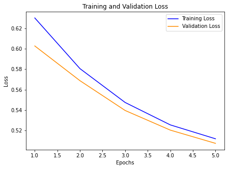

```python
plot(history_base.history['loss'], history_base.history['val_loss'], "loss")
```

#### Baseline Model: Accuracy

Plot the training accuracy against the validation accuracy.

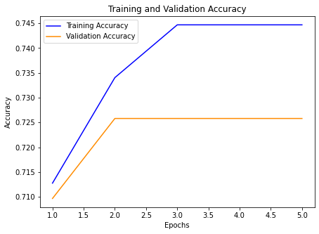

```python
plot(history_base.history['acc'], history_base.history['val_acc'], "acc")
```

#### Baseline Model: Evaluation

Evaluate the model against X_val and y_val.

```python
result_base = model_base.evaluate(X_val, y_val)

print("\nBaseline Loss     : " + str(int(result_base[0] * 100)) + "%")
print("Baseline Accuracy : " + str(int(result_base[1] * 100)) + "%")
```

```
Baseline Loss     : 50%
Baseline Accuracy : 72%
```

As you can see, the baseline model has an accuracy that is more than 50%. This means that model has achieved statistical power, and that the data set can be used to make accurate predictions.

### Developing an Overfitting Model

To figure out how big of a model is required to get a good fit, an overfitting model will developed. The way to make an overfitting model is by adding layers, making the layers bigger and training for more epochs.

Build a new model that has bigger and more layers.

```python
tf.random.set_seed(3)
model_overfit = models.Sequential()
model_overfit.add(layers.Dense(64, activation = 'relu', input_shape = (22,)))
model_overfit.add(layers.Dense(32, activation = 'relu'))
model_overfit.add(layers.Dense(16, activation = 'relu'))
model_overfit.add(layers.Dense(16, activation = 'relu'))
model_overfit.add(layers.Dense(16, activation = 'relu'))
model_overfit.add(layers.Dense(8, activation = 'relu'))
model_overfit.add(layers.Dense(1, activation = 'sigmoid'))
model_overfit.compile(optimizer = 'adam', loss = 'binary_crossentropy', metrics = ['acc'])
```

Train the model using 100 epochs.

```python
history_overfit = model_overfit.fit(
    partial_X_train, partial_y_train, epochs = 100, batch_size = 1, validation_data = (X_val, y_val), verbose = 0
)
```

#### Overfitting Model: Loss

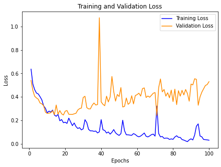

```python
plot(history_overfit.history['loss'], history_overfit.history['val_loss'], "loss")
```

This model is shown to be overfitting as the **training loss continues to decrease with experience**, while the **validation loss decreases to a point, before increasing again**.

#### Overfitting Model: Accuracy

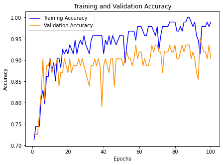

```python
plot(history_overfit.history['acc'], history_overfit.history['val_acc'], "acc")
```

#### Overfitting Model: Evaluation

```python
result_overfit = model_overfit.evaluate(X_val, y_val)

print("\nOverfit Loss     : " + str(int(result_overfit[0] * 100)) + "%")
print("Overfit Accuracy : " + str(int(result_overfit[1] * 100)) + "%")
```

```
Overfit Loss     : 52%
Overfit Accuracy : 90%
```

### Regularizing the Model and Hyperparameter Tuning

#### K-Fold Validation

Since the size of X_train is only (156, 22), I will be using K-Fold validation to make the data more reliable.

The function will contain comments to explain the code more in-depth.

```python
# K-Fold Validation code taken and modified from Chollet, François. “Deep Learning with Python.” p. 87-89

def k_fold_validation(X_train, y_train, epoch, build):
    '''
    Performs K-Fold Validation on training data that is limited.

    Inputs
    ------
    X_train : training data
    y_train : test data
    epoch   : number of epochs
    build   : model function

    Outputs
    -------
    acc_history      : equivalent to history.history['acc']
    val_acc_history  : equivalent to history.history['val_acc']
    loss_history     : equivalent to history.history['loss']
    val_loss_history : equivalent to history.history['val_loss']
    loss_scores      : loss evaluation of model
    acc_scores       : accuracy evaluation of model
    '''

    # train data for k folds
    k = 4
    # index is used to split the data into [index] size
    index = len(X_train) // k
    # lists to store each history.history['#']
    acc_histories = []
    loss_histories = []
    val_acc_histories = []
    val_loss_histories = []
    # lists to store each evaluation
    all_acc_scores = []
    all_loss_scores = []
    # loop through k
    for i in range(k):
        print('processing fold', i)
        # split X_train and y_train into partial_X_train, partial_y_train, X_val and y_val
        X_val = X_train[i * index: (i + 1) * index]
        y_val = y_train[i * index: (i + 1) * index]
        partial_X_train = np.concatenate([X_train[:i * index], X_train[(i + 1) * index:]], axis = 0)
        partial_y_train = np.concatenate([y_train[:i * index], y_train[(i + 1) * index:]], axis = 0)
        # build the model
        model = build()
        # train model using partial_X_train, partial_y_train, X_val and y_val
        history = model.fit(
            partial_X_train, partial_y_train, validation_data = (X_val, y_val), epochs = epoch, batch_size = 1, verbose = 0
        )
        # evaluate the model against X_val and y_val
        results = model.evaluate(X_val, y_val, verbose = 0)
        # retrieve each history.history[#] value
        acc = history.history['acc']
        loss = history.history['loss']
        val_acc = history.history['val_acc']
        val_loss = history.history['val_loss']
        # store into the corresponding list
        acc_histories.append(acc)
        loss_histories.append(loss)
        val_acc_histories.append(val_acc)
        val_loss_histories.append(val_loss)
        # store evaluation values into corresponding list
        all_loss_scores.append(results[0])
        all_acc_scores.append(results[1])
    # once loop has completed
    # loop through the lists and calculate the mean for each epoch
    acc_history = [np.mean([x[i] for x in acc_histories]) for i in range(epoch)]
    loss_history = [np.mean([x[i] for x in loss_histories]) for i in range(epoch)]
    val_acc_history = [np.mean([x[i] for x in val_acc_histories]) for i in range(epoch)]
    val_loss_history = [np.mean([x[i] for x in val_loss_histories]) for i in range(epoch)]
    # calculate mean of scores
    loss_scores = np.mean(all_loss_scores)
    acc_scores = np.mean(all_acc_scores)
    # return values
    return acc_history, val_acc_history, loss_history, val_loss_history, loss_scores, acc_scores
```

#### Attempt One — Adding/Removing Layers

For this attempt, we will try adding and removing layers from the overfitting model. Let's try removing a few hidden layers. Additionally, let's use the K-Fold validation to build the model.

Commented lines of code are codes that were edited, added or removed from the previous model, model_overfit().

```
processing fold 0
processing fold 1
processing fold 2
processing fold 3
```

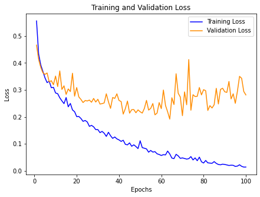

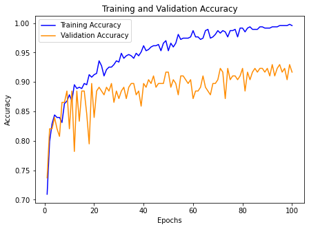

```
Loss     : 28%
Accuracy : 91%
```

```python
def model_one():
    tf.random.set_seed(3)
    model = models.Sequential()
    model.add(layers.Dense(64, activation = 'relu', input_shape = (22,)))
    # model.add(layers.Dense(32, activation = 'relu'))
    # model.add(layers.Dense(16, activation = 'relu'))
    # model.add(layers.Dense(16, activation = 'relu'))
    model.add(layers.Dense(16, activation = 'relu'))
    model.add(layers.Dense(8, activation = 'relu'))
    model.add(layers.Dense(1, activation = 'sigmoid'))
    model.compile(optimizer = 'adam', loss = 'binary_crossentropy', metrics = ['acc'])
    return model

acc_one, val_acc_one, loss_one, val_loss_one, loss_scores_one, acc_scores_one = k_fold_validation(
    X_train, y_train, epoch = 100, build = model_one
)

plot(loss_one, val_loss_one, "loss")
plot(acc_one, val_acc_one, "acc")

print("Loss     : " + str(int(loss_scores_one * 100)) + "%")
print("Accuracy : " + str(int(acc_scores_one * 100)) + "%")
```

Commented lines of code are codes that were edited, added or removed from the previous model, model_one().

```
processing fold 0
processing fold 1
processing fold 2
processing fold 3
```

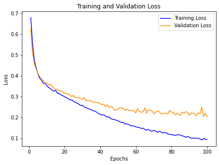

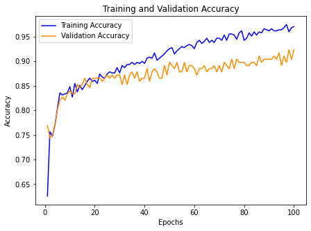

```
Loss     : 20%
Accuracy : 92%
```

```python
def model_two():
    tf.random.set_seed(3)
    model = models.Sequential()
    # model.add(layers.Dense(64, activation = 'relu', input_shape = (22,)))
    model.add(layers.Dense(16, activation = 'relu', input_shape = (22,)))
    # model.add(layers.Dense(16, activation = 'relu'))
    model.add(layers.Dense(8, activation = 'relu'))
    model.add(layers.Dense(1, activation = 'sigmoid'))
    model.compile(optimizer = 'adam', loss = 'binary_crossentropy', metrics = ['acc'])
    return model

acc_two, val_acc_two, loss_two, val_loss_two, loss_scores_two, acc_scores_two = k_fold_validation(
    X_train, y_train, epoch = 100, build = model_two
)

plot(loss_two, val_loss_two, "loss")
plot(acc_two, val_acc_two, "acc")

print("Loss     : " + str(int(loss_scores_two * 100)) + "%")
print("Accuracy : " + str(int(acc_scores_two * 100)) + "%")
```

This model is certainly much better than the one from **model_one()**. How about when we add another layer to the model in **model_two()**?

Commented lines of code are codes that were edited, added or removed from the previous model, model_two().

```
processing fold 0
processing fold 1
processing fold 2
processing fold 3
```

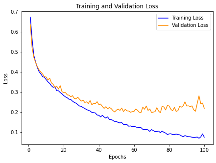

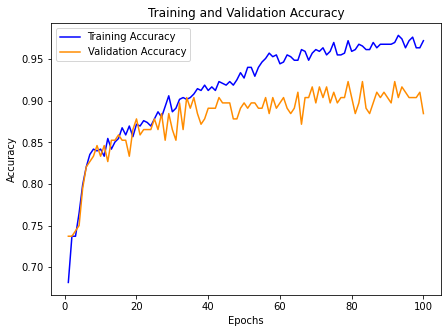

```
Loss     : 21%
Accuracy : 88%
```

```python
def model_three():
    tf.random.set_seed(3)
    model = models.Sequential()
    model.add(layers.Dense(16, activation = 'relu', input_shape = (22,)))
    model.add(layers.Dense(8, activation = 'relu')) # ADDED
    model.add(layers.Dense(8, activation = 'relu'))
    model.add(layers.Dense(1, activation = 'sigmoid'))
    model.compile(optimizer = 'adam', loss = 'binary_crossentropy', metrics = ['acc'])
    return model

acc_three, val_acc_three, loss_three, val_loss_three, loss_scores_three, acc_scores_three = k_fold_validation(
    X_train, y_train, epoch = 100, build = model_three
)

plot(loss_three, val_loss_three, "loss")
plot(acc_three, val_acc_three, "acc")

print("Loss     : " + str(int(loss_scores_three * 100)) + "%")
print("Accuracy : " + str(int(acc_scores_three * 100)) + "%")
```

Judging from all plotted graphs, **model_two()** seems to be the model with the current best parameters, with the lowest loss and highest accuracy.

#### Attempt Two — Training Lesser/More Epochs

Using **model_two()**, let's test whether the number of epochs during training affects the model. We will first train for twice the current number of epochs, then half of it.

```
processing fold 0
processing fold 1
processing fold 2
processing fold 3
```

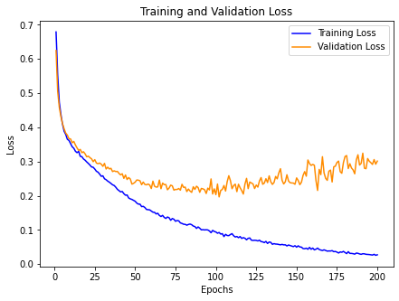

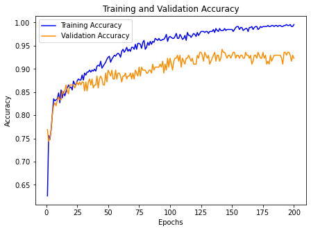

```
Loss     : 30%
Accuracy : 92%
```

```python
acc_four, val_acc_four, loss_four, val_loss_four, loss_scores_four, acc_scores_four = k_fold_validation(
    X_train, y_train, epoch = 200, build = model_two
)

plot(loss_four, val_loss_four, "loss")
plot(acc_four, val_acc_four, "acc")

print("Loss     : " + str(int(loss_scores_four * 100)) + "%")
print("Accuracy : " + str(int(acc_scores_four * 100)) + "%")
```

```
processing fold 0
processing fold 1
processing fold 2
processing fold 3
```

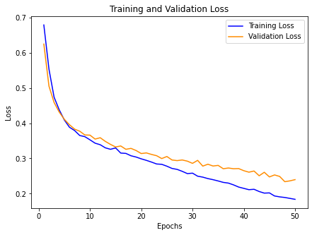

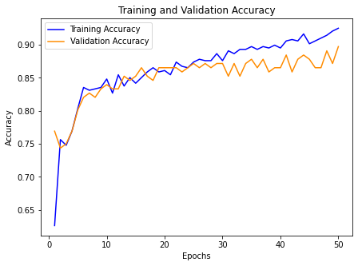

```
Loss     : 23%
Accuracy : 89%
```

```python
acc_five, val_acc_five, loss_five, val_loss_five, loss_scores_five, acc_scores_five = k_fold_validation(
    X_train, y_train, epoch = 50, build = model_two
)

plot(loss_five, val_loss_five, "loss")
plot(acc_five, val_acc_five, "acc")

print("Loss     : " + str(int(loss_scores_five * 100)) + "%")
print("Accuracy : " + str(int(acc_scores_five * 100)) + "%")
```

Training **200** epochs achieves the same accuracy as **100** epochs, but at a higher loss. Moreover, training at **50** epochs lowers accuracy. For these reasons, we will continue to use **100** epochs, which has a loss of 20% and an accuracy of 92%.

#### Attempt Three — Adding Dropout

The current parameters are still not generating a good fit, so we will try more methods, such as adding dropout.

Commented lines of code are codes that were edited, added or removed from the model with the best parameters, model_two().

```
processing fold 0
processing fold 1
processing fold 2
processing fold 3
```

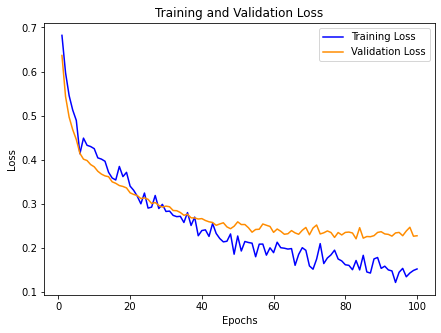

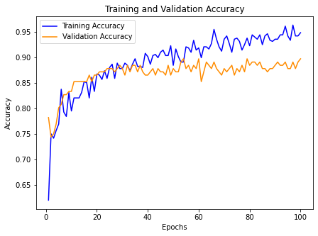

```
Loss     : 22%
Accuracy : 89%
```

```python
def model_dropout():
    tf.random.set_seed(3)
    model = models.Sequential()
    model.add(layers.Dense(16, activation = 'relu', input_shape = (22,)))
    model.add(layers.Dropout(0.2)) # dropout added
    model.add(layers.Dense(8, activation = 'relu'))
    model.add(layers.Dropout(0.2)) # dropout added
    model.add(layers.Dense(1, activation = 'sigmoid'))
    model.compile(optimizer = 'adam', loss = 'binary_crossentropy', metrics = ['acc'])
    return model

acc_six, val_acc_six, loss_six, val_loss_six, loss_scores_six, acc_scores_six = k_fold_validation(
    X_train, y_train, epoch = 100, build = model_dropout
)

plot(loss_six, val_loss_six, "loss")
plot(acc_six, val_acc_six, "acc")

print("Loss     : " + str(int(loss_scores_six * 100)) + "%")
print("Accuracy : " + str(int(acc_scores_six * 100)) + "%")
```

Adding dropout does not seem to have a good effect on the training model.

#### Attempt Four — Adding Regularization

Let's try adding L2 Regularization to the model this time.

Commented lines of code are codes that were edited, added or removed from the model with the best parameters, model_two().

```
processing fold 0
processing fold 1
processing fold 2
processing fold 3
```

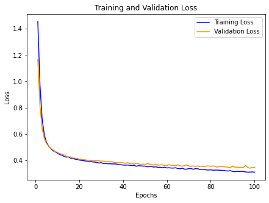

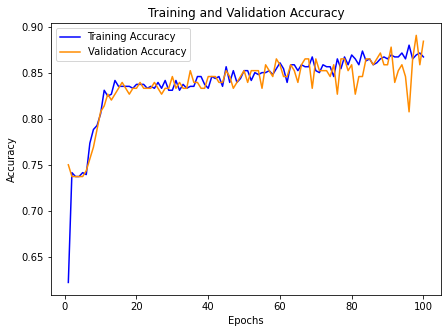

```
Loss     : 34%
Accuracy : 88%
```

```python
def model_regularization():
    tf.random.set_seed(3)
    model = models.Sequential()
    model.add(layers.Dense(16, activation = 'relu', input_shape = (22,)))
    model.add(layers.Dense(8, activation = 'relu', kernel_regularizer = regularizers.l2(l = 0.1))) # L2 regularization added
    model.add(layers.Dense(1, activation = 'sigmoid'))
    model.compile(optimizer = 'adam', loss = 'binary_crossentropy', metrics = ['acc'])
    return model

acc_seven, val_acc_seven, loss_seven, val_loss_seven, loss_scores_seven, acc_scores_seven = k_fold_validation(
    X_train, y_train, epoch = 100, build = model_regularization
)

plot(loss_seven, val_loss_seven, "loss")
plot(acc_seven, val_acc_seven, "acc")

print("Loss     : " + str(int(loss_scores_seven * 100)) + "%")
print("Accuracy : " + str(int(acc_scores_seven * 100)) + "%")
```

The way we tell if a model shows a good fit is:

1. The **training loss decreases to a point of stability**.
2. The **validation loss decreases to a point of stability and has a small gap with the training loss**.

Looking at the training model that has L2 Regularization, the model shows a good fit.

## Results

Using **model_regularization()**, we will re-train the model. If the models have consistent performance, we will be able to say that we have achieved a well-behaved model.

This time, instead of using K-Fold validation, we will train the data using **partial_X_train**, **partial_y_train**, **X_val** and **y_val**, as well as evaluating the model using **X_val** and **y_val**.

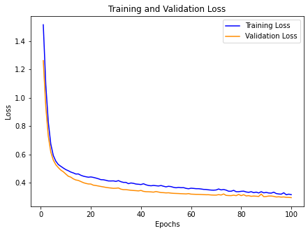

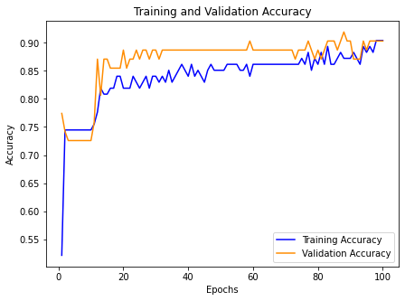

```
Evaluation Loss     : 29%
Evaluation Accuracy : 90%
```

```python
model_eval_one = model_regularization()
history_eval_one = model_eval_one.fit(
    partial_X_train, partial_y_train, epochs = 100, batch_size = 1, validation_data = (X_val, y_val), verbose = 0
)
results_eval_one = model_eval_one.evaluate(X_val, y_val)

plot(history_eval_one.history['loss'], history_eval_one.history['val_loss'], "loss")
plot(history_eval_one.history['acc'], history_eval_one.history['val_acc'], "acc")

print("Evaluation Loss     : " + str(int(results_eval_one[0] * 100)) + "%")
print("Evaluation Accuracy : " + str(int(results_eval_one[1] * 100)) + "%")
```

The next model will be trained using **X_train**, **y_train**, **X_test** and **y_test**. Evaluation will be done with **X_test** and **y_test**.

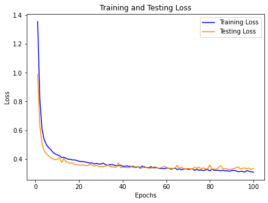

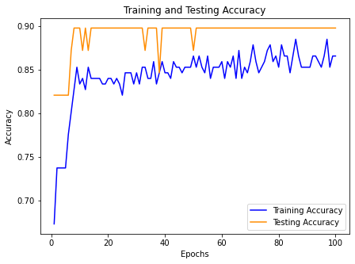

```
Evaluation Loss     : 33%
Evaluation Accuracy : 89%
```

```python
model_eval_two = model_regularization()
history_eval_two = model_eval_two.fit(
    X_train, y_train, epochs = 100, batch_size = 1, verbose = 0, validation_data = (X_test, y_test)
)
results_eval_two = model_eval_two.evaluate(X_test, y_test)

plt.clf()
epochs = range(1, len(history_eval_two.history['loss']) + 1)
plt.figure(figsize = (7,5))
plt.plot(epochs, history_eval_two.history['loss'], 'b', label = 'Training Loss', color = 'blue')
plt.plot(epochs, history_eval_two.history['val_loss'], 'b', label = 'Testing Loss', color = 'darkorange')
plt.title('Training and Testing Loss')
plt.xlabel('Epochs')
plt.ylabel('Loss')
plt.legend()
plt.show()

plt.clf()
epochs = range(1, len(history_eval_two.history['acc']) + 1)
plt.figure(figsize = (7,5))
plt.plot(epochs, history_eval_two.history['acc'], 'b', label = 'Training Accuracy', color = 'blue')
plt.plot(epochs, history_eval_two.history['val_acc'], 'b', label = 'Testing Accuracy', color = 'darkorange')
plt.title('Training and Testing Accuracy')
plt.xlabel('Epochs')
plt.ylabel('Accuracy')
plt.legend()
plt.show()

print("Evaluation Loss     : " + str(int(results_eval_two[0] * 100)) + "%")
print("Evaluation Accuracy : " + str(int(results_eval_two[1] * 100)) + "%")
```

## Conclusion

Looking back on the last three plots, we can safely say that a well-behaved model has been achieved. The results between them are consistent, with each line reaching stability. The accuracy for each of them has also beaten the baseline model, which stands at 72%, while the average accuracy of the last three is 89%. I could have used Hold-Out validation on the dataset, however I found that it was not optimal as the model kept overfitting, hence the change to K-Fold validation. However, even with the change of evaluation protocol, only by adding L2 regularizer was the model able to achieve a good fit. Though, it is not to say that there are not other ways that I did not explore that may or may not have been able to improve the models.

### Citations

Max A. Little, Patrick E. McSharry, Eric J. Hunter, Lorraine O. Ramig (2008), *'Suitability of dysphonia measurements for telemonitoring of Parkinson's disease'*, IEEE Transactions on Biomedical Engineering  
*'Exploiting Nonlinear Recurrence and Fractal Scaling Properties for Voice Disorder Detection'*, Little MA, McSharry PE, Roberts SJ, Costello DAE, Moroz IM. BioMedical Engineering OnLine 2007, 6:23 (26 June 2007)  
Chollet, François. *“Deep Learning with Python.”* (2017) p. 68-76, 87-90, 111-155.

### References

- [Parkinson's Data Set](https://archive.ics.uci.edu/ml/datasets/parkinsons)
- [Preprocessing Data](https://scikit-learn.org/stable/modules/preprocessing.html)
- [Pandas DataFrame to Tensor](https://www.tensorflow.org/tutorials/load_data/pandas_dataframe)
- [Dropout Regularization in Deep Learning Models With Keras](https://machinelearningmastery.com/dropout-regularization-deep-learning-models-keras/)
- [Regularization in TensorFlow using Keras API](https://johnthas.medium.com/regularization-in-tensorflow-using-keras-api-48aba746ae21)